# Objectives

## Overview

### Overview

My research is broadly focused on how climate change will affect an organism’s ability to adapt to their envrionment, and more specifcially focused on how movement into more suitable environments is a solution organisms might utalize. To examine these ideas, I have developed projects that look at avian movement ecology and biogeography in the Great Basin. By looking at patterns in avian abundance both temporatlly and spatially, I hope to better understand how climate change will impact avian communities into the future.

#### Background

The Great Basin is home to over 300 species of breeding birds. My lab group has been surveying sites in the Great Basin since 2001. We have collected data on avian occupancy and abundance, vegetation, nest sites, and more recently for my dissertation work microclimate and insect biomass. Because we visit each location three times per season and survey for birds, I was able to create models that examined how the avian community changes throughout the breeding season. Check out the Map tab to look at our sites!

#### Within-season dispersal

A dominant paradigm in ornithology is that birds arrive on their breeding grounds, establish a territory, and remain there until it is time to molt or migrate. However, during my five field seasons in the Great Basin I started to notice that for some species, something else might be going on. I consistently saw some species of birds at lower elevations in the beginning of the breeding season, and higher elevations later in the breeding season. Are some species switching territories during their breeding season? Why are some species moving and others not? Why might within season movement occur? I decided to build some models that would help answer those questions. Check out the Within-Season Dispersal tab for more info on this project.

#### Elevation Range Shifts

How do birds respond to climate change? Because birds are a highly vagile species, it is thought that one of the main ways bird are responding is through movement to more suitable habitats. Is climate change driving avian movements at our Great Basin sites?

This project aims to examine if elevational range shifts, or perhaps more accurately population-level shifts, are occurring at our Great Basin sites. Because we have a long term data set going back to 2002, I will be able to determine if species of birds have shifted elevationally in response to increasing temperature or changing precipitation regimes in a ~20 year period. If climate change is responsible for shifting species’ ranges, it could have big consequences for conservation of these species into the future.

#### Data Collection

What sort of data are we collecting to answer these questions? All sorts!

- Avian occupancy and abundance
- Vegetational composition of sites
- Nest sites for specific species (dissertation work of Frank Fogarty)
- Microclimate using HOBO data loggers
- Insect biomass using sticky traps and malaise traps
- Phenology of plant species known to be part of passerine diet

Through this data collection and statistical models, I hope to influence avian conservation decisions in the Great Basin, and examine current conservation practices in the context of passerine species.

# Map

## Mapping

### Spatial Data

Avian sampling through point count surveys has occurred at multiple locations throughout the Great Basin. Zoom in to see site where I have collected data on microclimate, plant phenology, and insect biomass.

#### Sampling locations for dissertation research

[interactive chart not shown]

# Within Season Movements

## Example

### Hypotheses: Why move?

There are three main hypotheses about *why* a bird would switch territories:

1. **Competition**: It might make sense for birds to move nest sites to avoid heavy competition.
2. **Predation**: This mainly pertains to nest predation. Depending on the time in the season when a nest is predated, it would make sense for birds to switch territories to avoid another predation event.
3. **Environmental Heterogenetiy**: If resources or other environmental variables are depleating at different rates across a landscape, birds might be switching nest sites to take advantage of better resources.

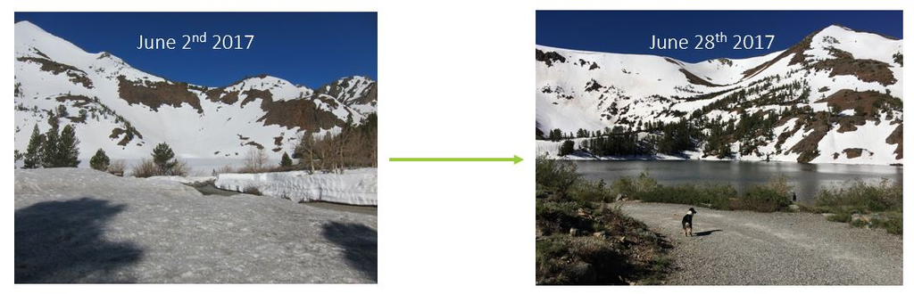